# Food Consumption In Indonesia

# Fisher LSD Test

#### our hypotheses for pairwise comparison

### $H_0$ : $\mu_1 - \mu_2$ = 0

and

### $H_1$ : $\mu_1 - \mu_2$ $\neq$ 0

```r
lsd_out<-LSD.test(df_anova,"df$`(B10) SOCIAL CLAS`",group=TRUE)
lsd_out
```

```
## $statistics
##    MSerror  Df     Mean       CV
##   111.5831 707 42.99296 24.56981
##
## $parameters
##         test p.ajusted                 name.t ntr alpha
##   Fisher-LSD      none df$`(B10) SOCIAL CLAS`   3  0.05
##
## $means
##              df$`(C15) % MONTHLY EXPENDITURE FOR FOOD`       std   r      LCL
## Lower Class                                   59.69106 11.322818 246 58.36878
## Middle Class                                  40.41016  9.862572 256 39.11396
## Upper Class                                   26.42308 10.466133 208 24.98507
##                   UCL Min Max Q25 Q50 Q75
## Lower Class  61.01334  23  76  57  59  69
## Middle Class 41.70635  18  67  34  38  43
## Upper Class  27.86108  18  76  23  25  26
##
## $comparison
## NULL
##
## $groups
##              df$`(C15) % MONTHLY EXPENDITURE FOR FOOD` groups
## Lower Class                                   59.69106      a
## Middle Class                                  40.41016      b
## Upper Class                                   26.42308      c
##
## attr(,"class")
## [1] "group"
```

#### From the results obtained, it is seen that “Lower Class”, “Middle Class” and “Upper Class” are separated into groups on their own (“a”,“b”,“c”). That meaning all different from each other

and

#### According to this result, there is a significant difference between the averages of the classes. We reject our hypothesis $H_0$.

## Checking the Normality Assumption

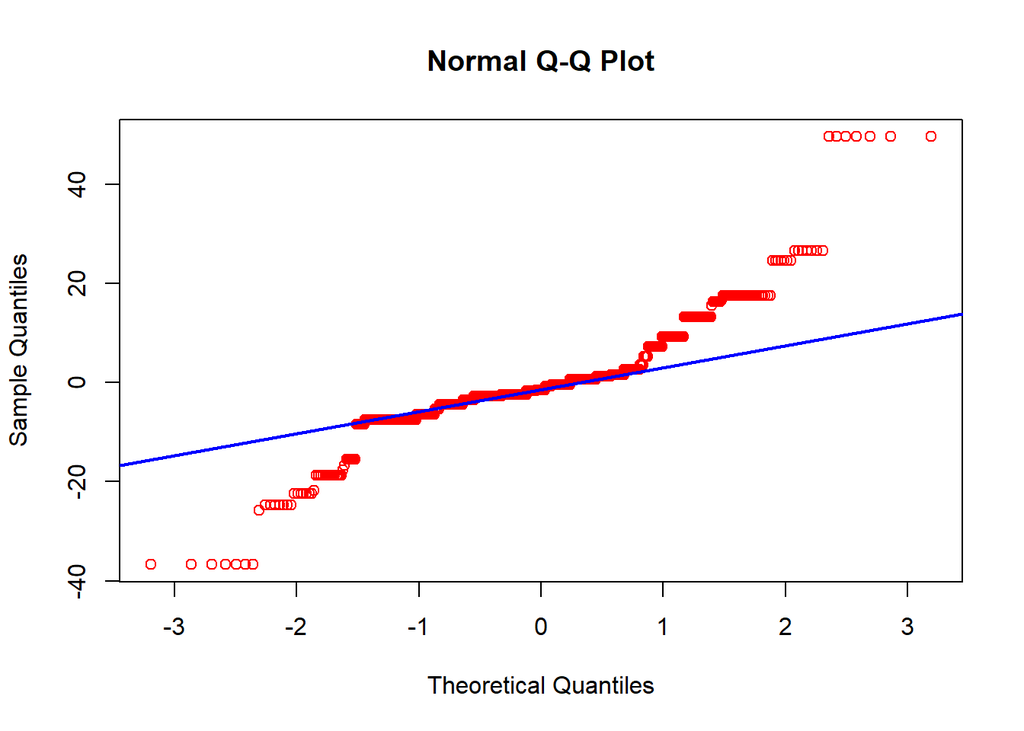

```r
qqnorm(resid(df_anova), main = "Normal Q-Q Plot", col = "red")
qqline(resid(df_anova), col = "blue", lwd = 2)
```

#### As seen in the graph, normality is not achieved.

```r
shapiro.test(residuals(df_anova))
```

```
##
##  Shapiro-Wilk normality test
##
## data:  residuals(df_anova)
## W = 0.86666, p-value < 2.2e-16
```

#### As a result of the Shapiro-Wilk normality test, our p value was found to be much smaller than 0.05. According to this result, we see that normality is not provided.

```r
ks.test(df_anova$residuals,"pnorm",mean=mean(df_anova$residuals),sd=sd(df_anova$residuals))
```

```
##
##  One-sample Kolmogorov-Smirnov test
##
## data:  df_anova$residuals
## D = 0.19317, p-value < 2.2e-16
## alternative hypothesis: two-sided
```

#### As seen in the test results, it does not meet the normality assumption. The residuals do not have a normal distribution.